# Project 2 Document

Thomas Closser

2024-05-21

# Introduction

The data set I chose to analyze was the *project2_data.csv set*. What I wanted to set out to do was to find if there was a significant difference between middle aged adults who worked and younger adults who worked and if they got COVID-19. This sample will be a difference in proportions between these two groups, with a large sample size of over 12,500 people. This is a huge sample, but I wanted to get as accurate data as I could so I can make a better prediction. However before I could start with this analysis, I needed to organize and subset my data to include what I needed.

The variables I was ended up using from the original data set was:  
- AGE  
- HOURSWRK  
- CVDDIAG

I would subset this further by excluding people above 60 years of age, since that was logically older than what is considered middle-aged, as well as those with greater than 0 hours of work per week. To clean this data a little bit, I also excluded any N/A values which were not inputted into the set originally. To finalize this subsetting I created a new variable called `Middle_Aged`. This was a binary variable which represented the low point of 40 years old to be categorized as “Middle Aged”, whereas those younger than 40 would be categorized as “Younger”. I did not want to extend my range beyond 60 years old because of the inherit inconsistencies in the age ranges past what is considered “middle-aged”. I preferred to have consistency and a full usable range of data.

With this, I was able to clean the data to a point where I could test my **question of interest:**  
- *Are Younger workers more likely to have COVID-19 than middle-aged workers?*  
The population of interest I want to question is the range of employed legal adults that are no older than 60.

# Analysis 1: Hypothesis Test

Firstly, I will categorize the workers into two groups:  
- $p_1$ being the population proportion of “younger” workers who did get COVID-19,

and

- $p_2$, the population proportion of “middle-aged” workers who got COVID-19.

These above will be my *parameters* which I will be using as a basis for my hypothesis tests. Since I want to test if there is a greater proportion of younger workers who got COVID-19 than the proportion of middle-aged workers who got COVID-19, my tests will be structured like this using the earlier parameters:

**$H_0:$** $p_1 - p_2 = 0$

**$H_a:$** $p_1 - p_2 > 0$

To begin, below is a visual representation of the proportion of workers who got COVID-19 and who did not get COVID-19, categorized by if they were middle-aged or younger.

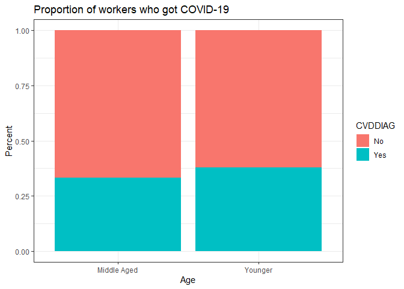

As we can see from our sample, the proportion of the middle-aged workers who got COVID-19 is around 34%, while the proportion of younger workers who got COVID-19 as a little above 37%. This is a slight difference, but it is important to note that this is not the grand majority, as over 60% of both younger and middle-aged workers do not have COVID-19.

Regarding the Ages themselves, the mean age within the data set was 40.41, with the median a little lower at 40.00. The standard deviation of age was 11.49, and as described earlier, the ranges were from 18 years old (legal adult), to 60 years old (oldest middle-age cap). This shows little skewing in the data between the categories of `Younger` workers and `Middle-Aged` workers.

In order to test if we can reject the null hypothesis that there is no difference between the proportion of younger workers who got COVID-19 and middle-aged workers who got COVID-19, we must create a distribution where the null is true, and compare an estimate from the sample to this null distribution in order to come to a conclusion.

I need to estimate the difference in proportions of who got COVID-19 between the `Younger` group and the `Middle-Aged` group. This was done like so:

$p_1 - p_2 = 0.0474$

- Where $p_1$ was the proportion of `Younger` working adults who got COVID-19
- and $p_2$ was the proportion of `Middle Aged` working adults who got COVID-19

Next is our distribution of the null hypothesis, and obtaining a p-value. The p-value will be measured next to a significance level of $\alpha = 0.05$:

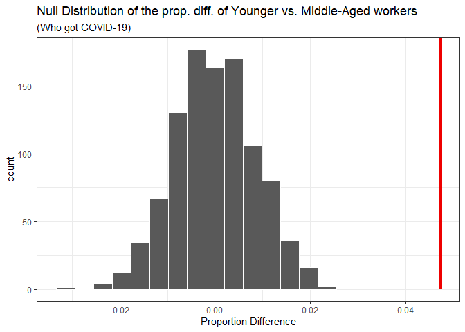

**P-value** = 0

What this value means, and what a p-value means, is that in a world where there is no difference between the proportion of younger workers who got COVID-19 and middle-aged workers who got COVID-19, we would get our estimate of 0.0474 for the difference in proportions between the two groups approximately 0% of the time.

With this evidence, we can say that:

- With a p-value of approximately 0, less than our significance level of 0.05, we have very strong evidence to reject the null hypothesis that there is no difference between the population proportion of younger workers who got COVID-19 and middle-aged workers who got COVID-19. We have sufficient evidence to accept the alternative hypothesis that the population proportion of younger workers who got COVID-19 is greater than the proportion of middle-aged workers who got COVID-19.

# Analysis 2: Confidence Interval

Now we have strong evidence to suggest that there *is* a difference between the two groups, we should get a confidence interval to tell us where the true population proportion difference lies.

We calculated earlier that the proportion of younger workers who got COVID-19 was greater than the proportion of middle-aged workers who got COVID-19 by **0.0474**. While this estimate is useful, since it tells me that there is a higher proportion of younger adults who got COVID-19 then middle-aged adults, I want to find if this estimate is *statistically significant* and if there is a more nuanced value of where the true population might lie. How this can be done is by finding the *Confidence Interval*, which will give us a range of values where the true population difference in proportions between middle-aged and younger workers who got COVID-19 lie.

Shown below is a bootstrap distribution of the proportion difference between “Younger” and “Middle-aged” workers who got COVID-19:

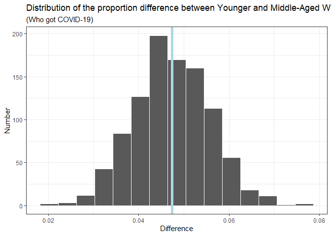

The center of this distribution as shown by the blue line is our earlier estimate of 0.0474, representing our *difference in proportions of workers who got COVID-19 who were younger and middle-aged*. The shape of the distribution appears to be relatively normal, meaning when we re-sampled our sample 1000 times, we eventually got to a spread like this. The spread of the data is relatively even, being bell shaped and generally clustering around our difference in proportions.

Before taking this confidence interval, the *significance level* that will be set will be $\alpha=0.05$, representing a 95% confidence interval. This interval was taken and is shown below:

```
## # A tibble: 1 × 2
##   lower_ci upper_ci
##      <dbl>    <dbl>
## 1   0.0313   0.0642
```

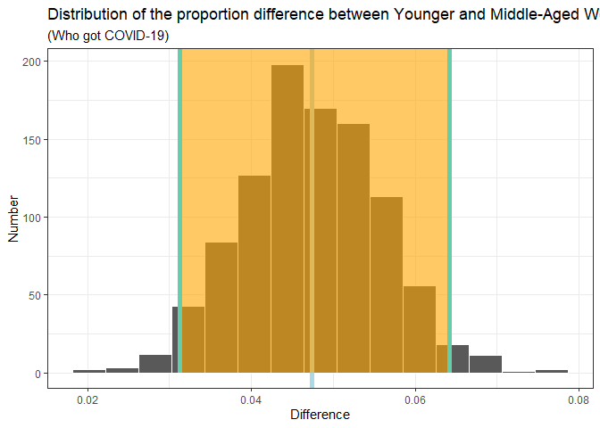

Here is a visual representation of the possible values our true estimate could lie in, shaded in the orange. In other words:

- We are 95% confident that the population proportion of younger workers who got COVID-19 is between 0.0313 and 0.0642 greater than the proportion of middle-aged workers who got COVID-19.

# Conclusion

In summary, we found sufficient evidence via *hypothesis testing* that there was a proportion difference between younger and middle-aged workers who got COVID-19 with the p-value of approximately 0. We then found the *confidence interval* of the true difference in proportions, and found that younger workers got COVID-19 between 3.13% and 6.42% more often than middle-aged workers. Both of these methods were needed in order to reach a conclusion. Our hypothesis testing allowed us to confirm that there was a proportional difference between younger adults and middle-aged adults, but that’s all it could do. We needed to next find the confidence interval of the true difference in proportions between the two groups for us to find which group had a larger proportion of COVID-19 successes, and in an interval what the true population difference was.

These results could be useful in showing the similarities between COVID-19 results between younger workers and older workers to show that the spread of positive cases are not as skewed towards one particular group. This could help show that COVID-19’s spread was not caused by one particular age group or generation. Some limitations to these results is that they do not take into account specific circumstances which could explain *how* they got COVID-19, rather just *who* has it and *how much more* compared to “x” or “y”.

I believe that a future study could expand upon this by including more variables regarding *where* they got COVID-19, or *how*. This could allow more depth and dimensions to the context of the current data, and potentially testing using a regression model would be a better way of explaining *how* something has happened.

# References

- Lynn A. Blewett, Julia A. Rivera Drew, Miriam L. King, Kari C.W. Williams, Annie Chen, Stephanie Richards, and Michael Westberry. IPUMS Health Surveys: National Health Interview Survey, Version 7.3 [dataset]. Minneapolis, MN: IPUMS, 2023. https://doi.org/10.18128/D070.V7.3